# EDA Assignment 4

Motoki Sugino

September 29, 2016

1. The dataset lake in the LearnEDA package (taken from the Minitab dataset collection) contains measurements of lakes in the Vilas andOneidacounties of northernWisconsin.  
   The variables are

AREA = area of lake in acres

DEPTH = maximum depth of lake in feet

PH = pH (acidity) measurement

WSHED = watershed area in square miles

HIONS = concentration of hydrogen ions

For two of these variables (that are not symmetric), find a transformation which makes the dataset symmetric. You can use any tool you want, including H quick method, inspection of mids, symmetry plots, etc. Demonstrate that your transformation has been symmetric.

```r
library(LearnEDA)
#lake
```

looking at each histgram

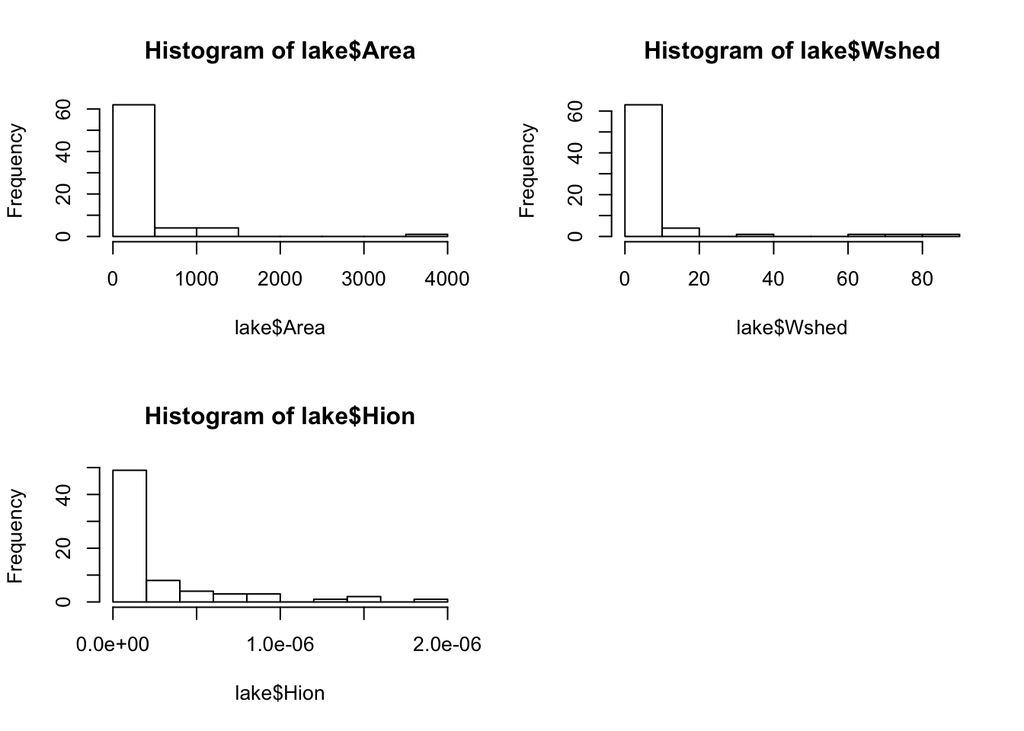

```r
par(mfrow=c(2, 2))
hist(lake$Area)
#hist(lake$Depth)
#hist(lake$PH)
hist(lake$Wshed)
hist(lake$Hion)
```

The variables, Area,Wshed and Hion, are not symmetric. Therefore, we are going to choose the variable Area and Wshed to perfrom the transformation for symmetric distribution.

# For Area

Now we are going to focus on the variable Area.

Shape of data

```r
aplpack::stem.leaf(lake$Area)
```

```
## 1 | 2: represents 120
##  leaf unit: 10
##             n: 71
##    12    0* | 222223333344
##    26    0. | 55555778899999
##   (11)   1* | 01122223344
##    34    1. | 6777788889
##    24    2* | 0112233
##    17    2. | 8
##    16    3* | 0
##    15    3. | 5579
##    11    4* | 33
##          4. |
##     9    5* | 3
## HI: 599 610 716 1065 1285 1352 1463 3585
```

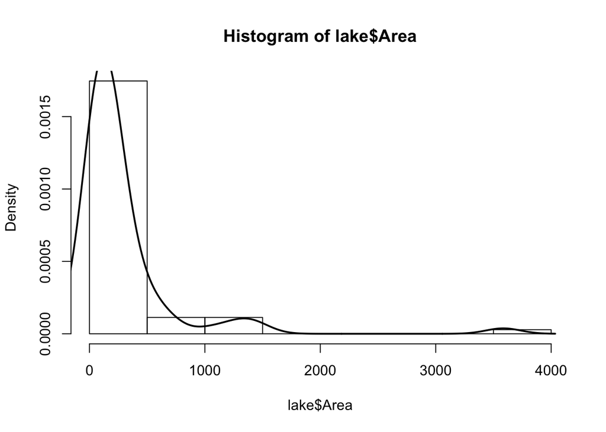

```r
hist(lake$Area, freq=FALSE)
lines(density(lake$Area, bw=150),lwd=2)
```

There is rigth skewedness in the distribution.

The power family

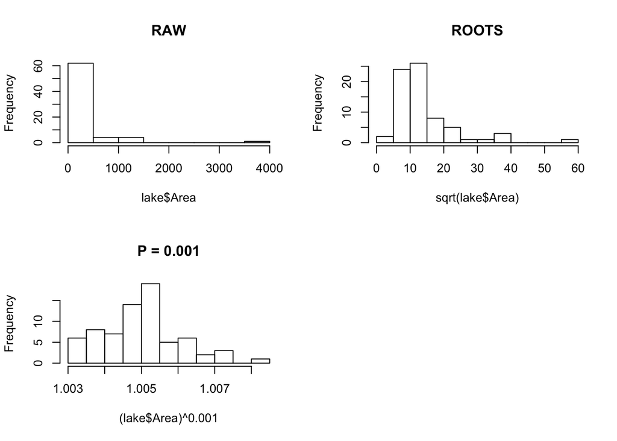

```r
par(mfrow=c(2, 2))
hist(lake$Area, main="RAW")
hist(sqrt(lake$Area), main="ROOTS")
hist((lake$Area) ^ 0.001, main="P = 0.001")
```

From the above plots, we can say that taking p=0.001 looks rougly symmetric.

Cheacking for symmetry by looking at midsummaries.

```r
letter.values <- lval(lake$Area)
letter.values$mids
```

```
## [1]  148.00  157.00  259.75  547.00  689.00  743.00 1803.50
```

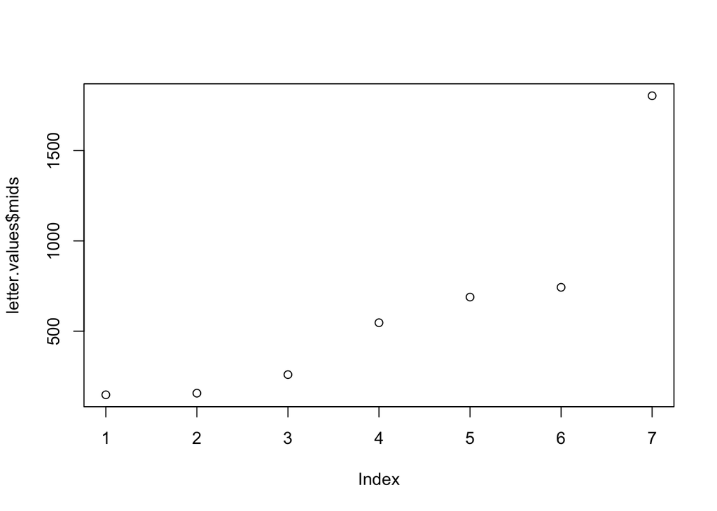

```r
plot(letter.values$mids)
```

You can see the right skewness since this sequence is in creasing.

We first try roots (p = .5).

```r
roots <- sqrt(lake$Area)
aplpack::stem.leaf(roots)
```

```
## 1 | 2: represents 12
##  leaf unit: 1
##             n: 71
##   10     f | 4455555555
##   17     s | 6677777
##   26    0. | 889999999
##   (9)   1* | 000111111
##   36     t | 222333333333
##   24     f | 4444455
##   17     s | 67
##   15    1. | 8899
##   11    2* | 00
##    9     t | 3
##    8     f | 44
##    6     s | 6
## HI: 32.6343377441614 35.8468966578698 36.7695526217005 38.2491829978106 59.8748695196908
```

```r
root.lv <- lval(roots)
root.lv
```

```
##   depth        lo       hi     mids   spreads
## M  36.0 12.165525 12.16553 12.16553  0.000000
## H  18.5  8.746381 15.41103 12.07870  6.664645
## E   9.5  5.873516 21.99567 13.93459 16.122153
## D   5.0  5.385165 32.63434 19.00975 27.249173
## C   3.0  5.099020 36.76955 20.93429 31.670533
## B   2.0  4.795832 38.24918 21.52251 33.453351
## A   1.0  4.690416 59.87487 32.28264 55.184454
```

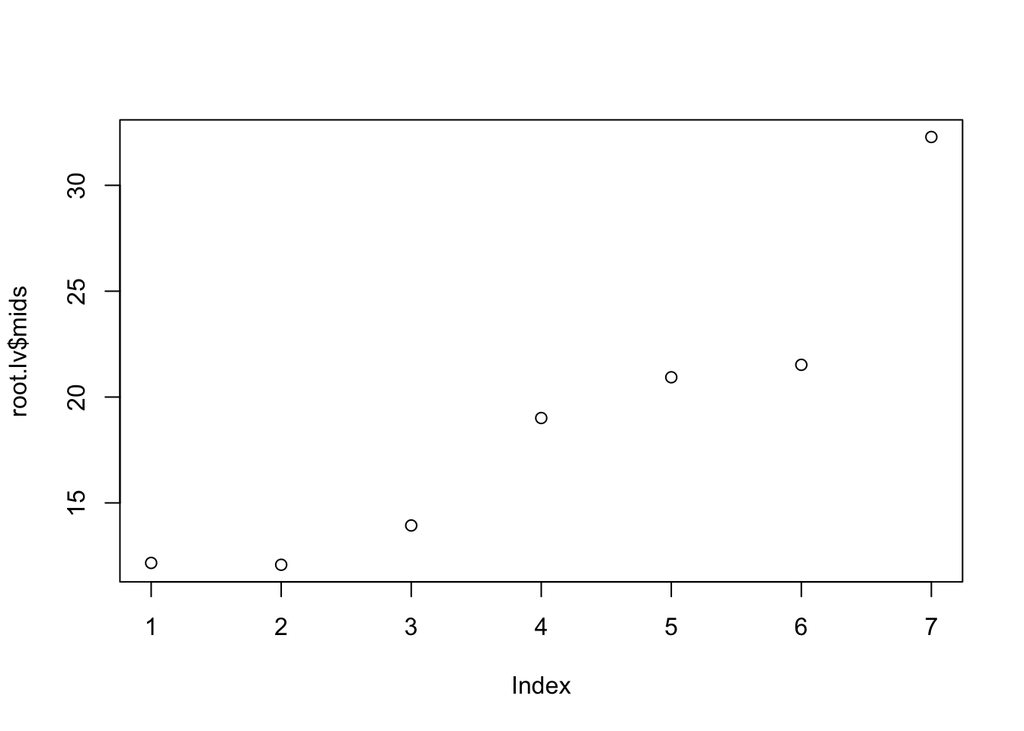

```r
plot(root.lv$mids)
```

```r
logs <- log(lake$Area)
aplpack::stem.leaf(logs)
```

```
## 1 | 2: represents 1.2
##  leaf unit: 0.1
##             n: 71
##     8    3* | 01233444
##    14    3. | 558899
##    21    4* | 0003344
##   (15)   4. | 555556778888889
##    35    5* | 001111122223334444
##    17    5. | 678899
##    11    6* | 00234
##     6    6. | 59
##     4    7* | 122
##          7. |
##     1    8* | 1
```

```r
logs.lv <- lval(logs)
logs.lv
```

```
##   depth       lo       hi     mids  spreads
## M  36.0 4.997212 4.997212 4.997212 0.000000
## H  18.5 4.337269 5.470165 4.903717 1.132896
## E   9.5 3.540854 6.179227 4.860041 2.638373
## D   5.0 3.367296 6.970730 5.169013 3.603434
## C   3.0 3.258097 7.209340 5.233718 3.951244
## B   2.0 3.135494 7.288244 5.211869 4.152750
## A   1.0 3.091042 8.184514 5.637778 5.093471
```

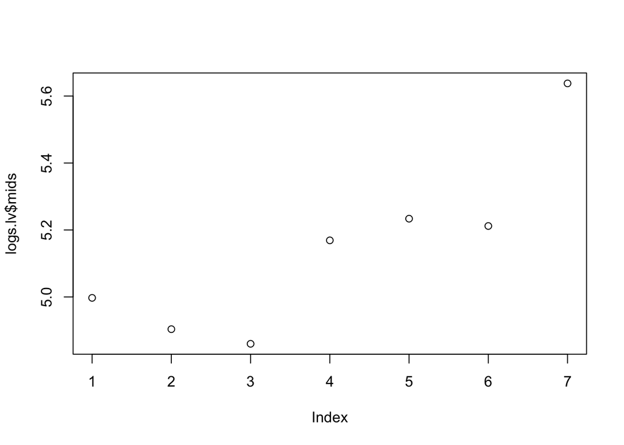

```r
plot(logs.lv$mids)
```

Looking the above graphs, we can see the taking log looks like the best reexpression. We are going to take a further investigation to check if taking log is the best.

```r
#if take p = −1/2     -1/sqrt(lake$Area) Further investigation
recroots <- - 1 / sqrt(lake$Area)
aplpack::stem.leaf(recroots)
```

```
## 1 | 2: represents 0.012
##  leaf unit: 0.001
##             n: 71
## LO: -0.21320071635561 -0.208514414057075
##    3    -19 | 6
##    6    -18 | 852
##    9    -17 | 441
##   10    -16 | 9
##         -15 |
##   12    -14 | 54
##   17    -13 | 87440
##         -12 |
##   19    -11 | 43
##   26    -10 | 6522111
##   29     -9 | 644
##   (8)    -8 | 99997721
##   34     -7 | 8665543322
##   24     -6 | 9886644
##   17     -5 | 973210
##   11     -4 | 87300
##    6     -3 | 70
##    4     -2 | 776
##    1     -1 | 6
```

```r
recroots.lv <- lval(recroots)
recroots.lv
```

```
##   depth          lo          hi        mids    spreads
## M  36.0 -0.08219949 -0.08219949 -0.08219949 0.00000000
## H  18.5 -0.11433422 -0.06488868 -0.08961145 0.04944555
## E   9.5 -0.17026472 -0.04557565 -0.10792018 0.12468907
## D   5.0 -0.18569534 -0.03064257 -0.10816895 0.15505277
## C   3.0 -0.19611614 -0.02719641 -0.11165627 0.16891972
## B   2.0 -0.20851441 -0.02614435 -0.11732938 0.18237006
## A   1.0 -0.21320072 -0.01670150 -0.11495111 0.19649922
```

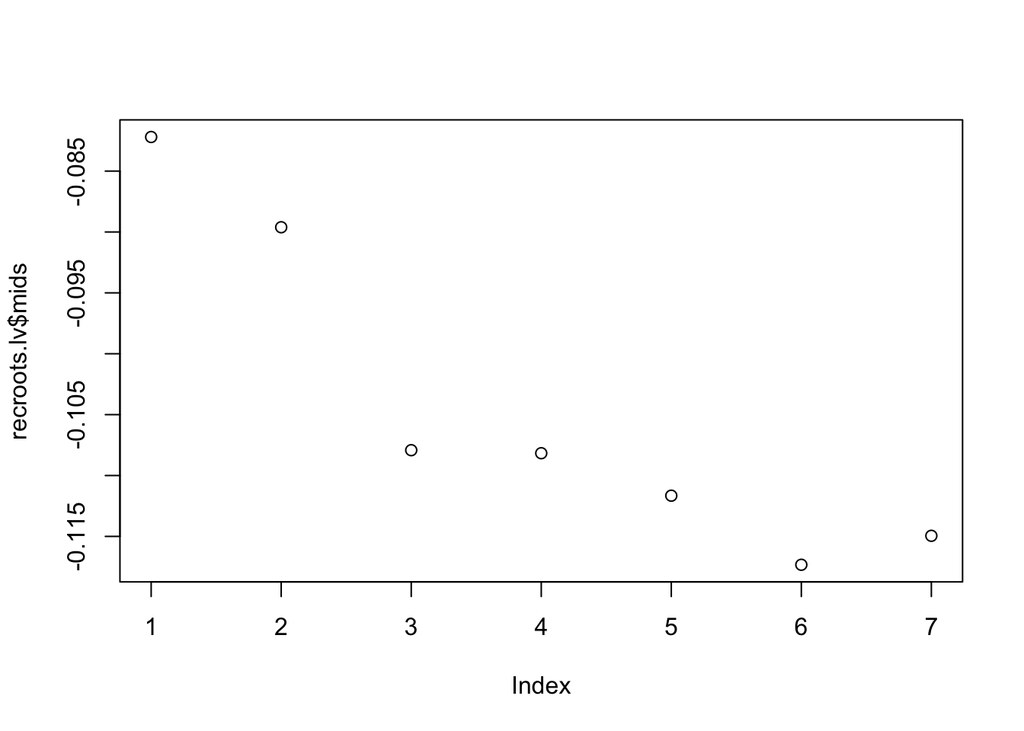

```r
plot(recroots.lv$mids)
```

Once again, taking log is the best option for this case since stemplot looks like more symmetric.

Next, we use Hinkley’s quick method.

```r
hinkley(roots)
```

```
##         h
## 0.3018693
```

```r
hinkley(logs)
```

```
##            h
## -0.006043786
```

```r
hinkley(recroots)
```

```
##          h
## -0.2442803
```

Looking at the values of d in Hinkley’s quick method, the correct reexpression appears to be between p=.5 and p=0, although the value closest to 0 corresponds to the log reexpression.

Checking at Symmetry Plot.

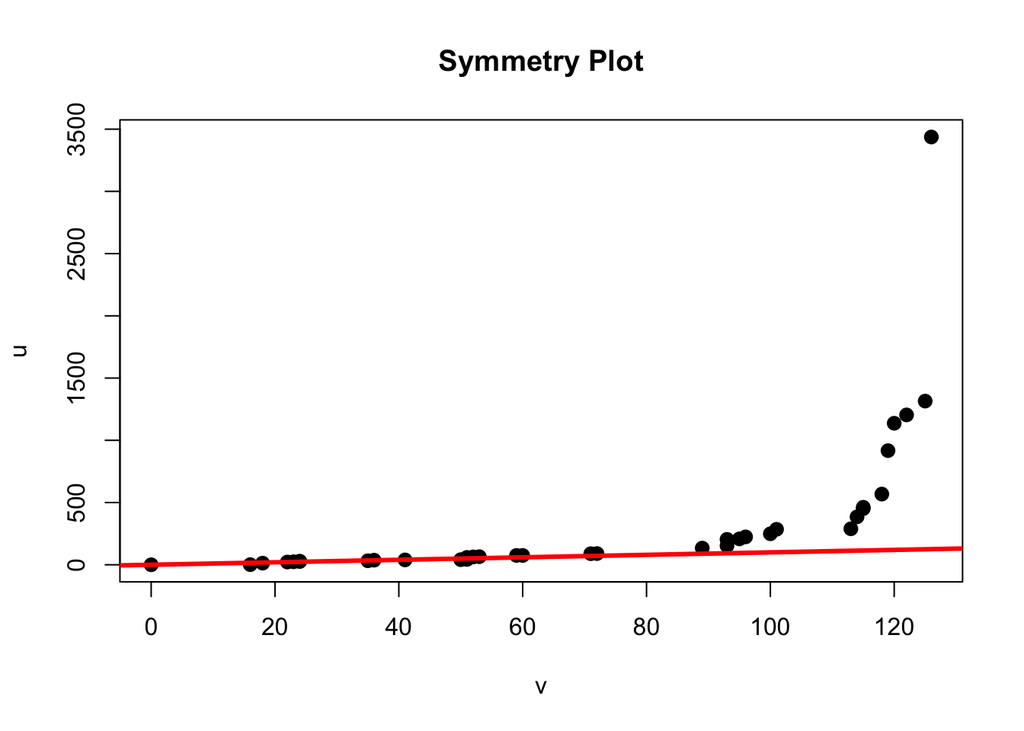

```r
symplot(lake$Area)
```

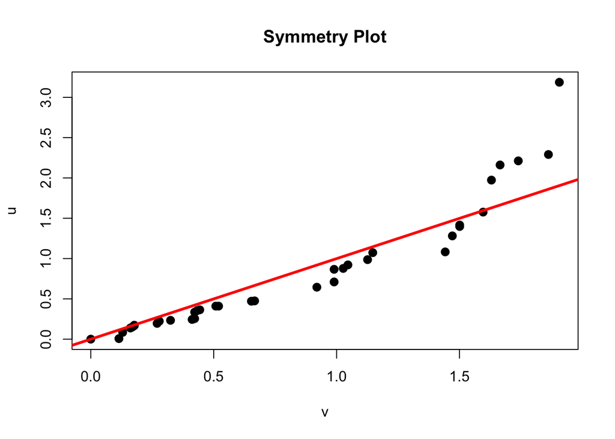

```r
symplot(logs)
```

For Area, taking log is the best reexpression for Area.Looking at the symmetry plot, the points roughly fall close to the line u=v, so we can say that the data is neraly symmetric. However, there is right skewedness in the end and one possible outlier.

Matched transformation.

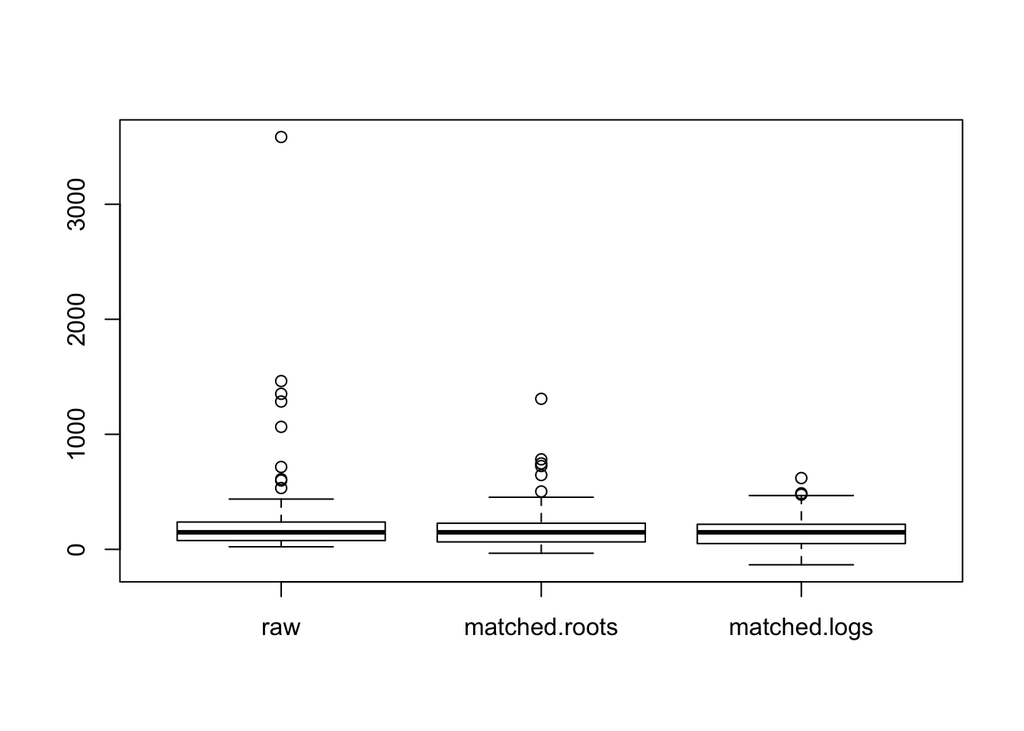

```r
#let x_0 = 148, the medain of the raw data
matched.roots <- 148 + (sqrt(lake$Area) - sqrt(148)) / (.5*148 ^ (-.5))
matched.logs <- 148 + (log10(lake$Area) - log10(148)) / (log10(exp(1)) / 148)

raw <-lake$Area
matched.roots <- mtrans(raw, 0.5)
matched.logs <- mtrans(raw, 0)
boxplot(data.frame(raw, matched.roots, matched.logs))
```

In conclusion, taking log is the best reexpression for the variable, Area, since it removes right skewedness and it looks like approximately symmetric. However, there is right skewedness in the end and one possible outlier as you can see it in the symmetry plot.

# For Wshed

```r
aplpack::stem.leaf(lake$Wshed)
```

```
## 1 | 2: represents 1.2
##  leaf unit: 0.1
##             n: 71
##    9    0* | 222333444
##   22    0. | 5567777888899
##   35    1* | 0000000000024
##   (6)   1. | 555578
##   30    2* | 000000000
##   21    2. | 55
##   19    3* | 000
##         3. |
##   16    4* | 00
##         4. |
##   14    5* | 0
##         5. |
##   13    6* | 34
## HI: 8 8 10 12 12 13 17 33 65 80 88
```

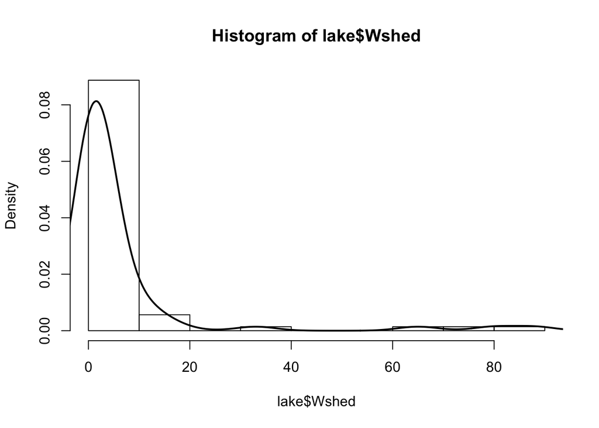

```r
hist(lake$Wshed, freq=FALSE)
lines(density(lake$Wshed, bw=4),lwd=2)
```

Once again, there is right skewedness in the distribution.

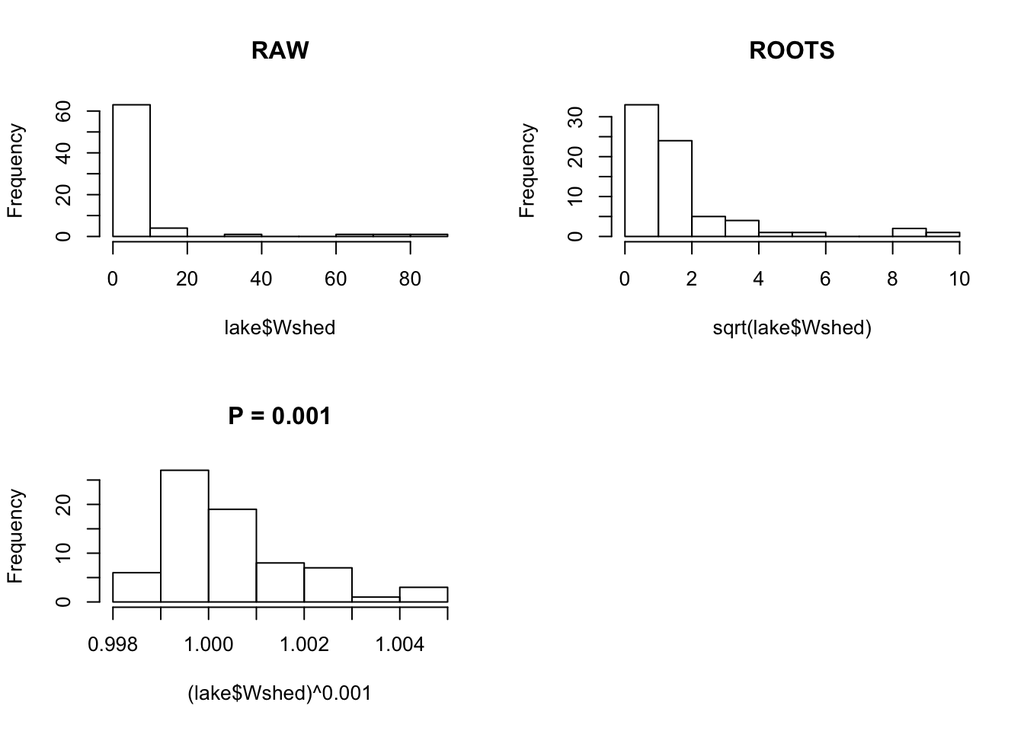

```r
par(mfrow=c(2, 2))
hist(lake$Wshed, main="RAW")
hist(sqrt(lake$Wshed), main="ROOTS")
hist((lake$Wshed) ^ 0.001, main="P = 0.001")
```

These histgram above have no symmetric.

```r
letter.values <- lval(lake$Wshed)
letter.values$mids
```

```
## [1]  1.500  1.900  4.725  8.650 32.600 40.100 44.100
```

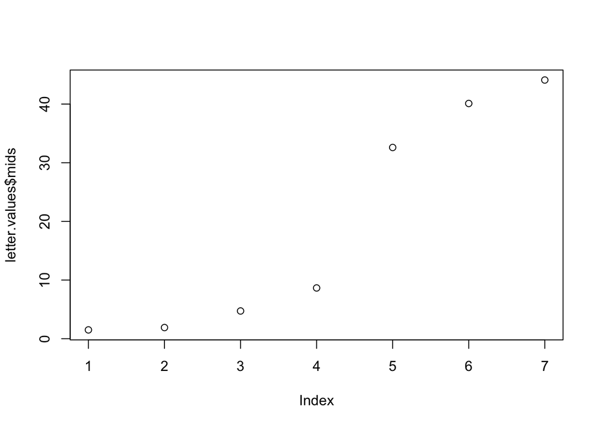

```r
plot(letter.values$mids)
```

You can see the right skewness since this sequence is in creasing.

taking roots

```r
roots <- sqrt(lake$Wshed)
aplpack::stem.leaf(roots)
```

```
## 1 | 2: represents 1.2
##  leaf unit: 0.1
##             n: 71
##    6     f | 444555
##   12     s | 666777
##   22    0. | 8888888899
##   35    1* | 0000000000001
##   (6)    t | 222233
##   30     f | 44444444455
##   19     s | 777
##         1. |
##   16    2* | 00
##   14     t | 2
##   13     f | 55
##          s |
##   11    2. | 88
##    9    3* | 1
## HI: 3.46410161513775 3.46410161513775 3.60555127546399 4.12310562561766 5.74456264653803 8.06225774829855 8.94427190999916 9.38083151964686
```

```r
root.lv <- lval(roots)
root.lv
```

```
##   depth        lo       hi     mids   spreads
## M  36.0 1.2247449 1.224745 1.224745 0.0000000
## H  18.5 0.8944272 1.732051 1.313239 0.8376236
## E   9.5 0.6697812 2.995352 1.832567 2.3255712
## D   5.0 0.5477226 4.123106 2.335414 3.5753831
## C   3.0 0.4472136 8.062258 4.254736 7.6150442
## B   2.0 0.4472136 8.944272 4.695743 8.4970583
## A   1.0 0.4472136 9.380832 4.914023 8.9336179
```

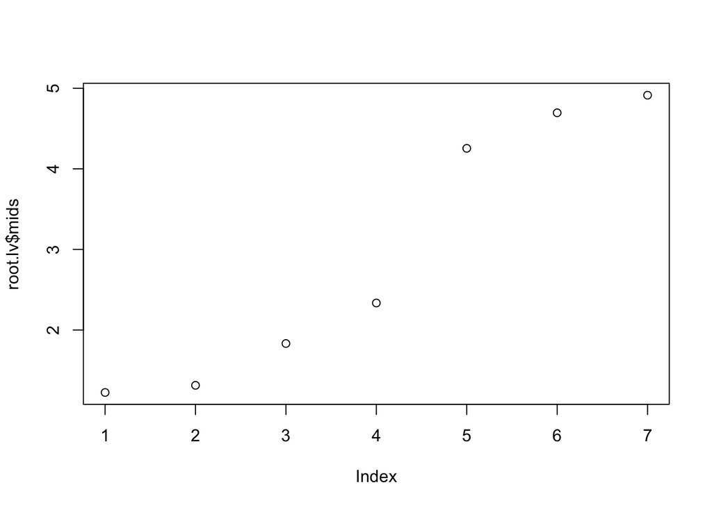

```r
plot(root.lv$mids)
```

```r
#take log
logs <- log(lake$Wshed)
aplpack::stem.leaf(logs)
```

```
## 1 | 2: represents 1.2
##  leaf unit: 0.1
##             n: 71
##     3    -1. | 666
##     6    -1* | 222
##    12    -0. | 999665
##    22    -0* | 3333222211
##   (17)    0* | 00000000000134444
##    32     0. | 5566666666699
##    19     1* | 00033
##    14     1. | 688
##    11     2* | 00344
##     6     2. | 58
##     4     3* | 4
## HI: 4.17438726989564 4.38202663467388 4.47733681447821
```

```r
logs.lv <- lval(logs)
logs.lv
```

```
##   depth         lo        hi      mids  spreads
## M  36.0  0.4054651 0.4054651 0.4054651 0.000000
## H  18.5 -0.2231436 1.0986123 0.4377344 1.321756
## E   9.5 -0.8047190 2.1910133 0.6931472 2.995732
## D   5.0 -1.2039728 2.8332133 0.8146203 4.037186
## C   3.0 -1.6094379 4.1743873 1.2824747 5.783825
## B   2.0 -1.6094379 4.3820266 1.3862944 5.991465
## A   1.0 -1.6094379 4.4773368 1.4339495 6.086775
```

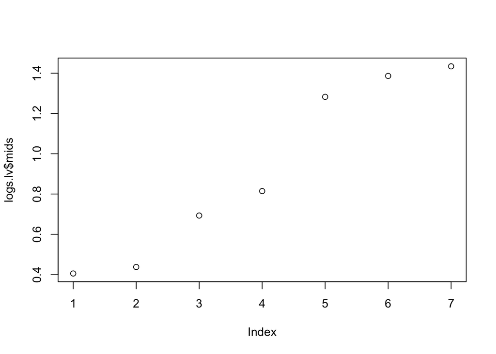

```r
plot(logs.lv$mids)
```

There is still right skewedness in the tail here. Taking log does not looks roughly symmetric.

```r
#if take p = −1/2     -1/sqrt(lake$Area) Further investigation
recroots <- - 1 / sqrt(lake$Wshed)
aplpack::stem.leaf(recroots)
```

```
## 1 | 2: represents 0.12
##  leaf unit: 0.01
##             n: 71
## LO: -2.23606797749979 -2.23606797749979 -2.23606797749979
##    6    -18 | 222
##         -17 |
##         -16 |
##    9    -15 | 888
##   11    -14 | 11
##         -13 |
##   12    -12 | 9
##   20    -11 | 99991111
##   33    -10 | 5500000000000
##   34     -9 | 1
##   (5)    -8 | 41111
##   32     -7 | 64000000000
##   21     -6 | 33
##   19     -5 | 77700
##   14     -4 | 4
##   13     -3 | 99551
##    8     -2 | 8874
##    4     -1 | 7210
```

```r
recroots.lv <- lval(recroots)
recroots.lv
```

```
##   depth         lo         hi       mids   spreads
## M  36.0 -0.8164966 -0.8164966 -0.8164966 0.0000000
## H  18.5 -1.1180340 -0.5773503 -0.8476921 0.5406837
## E   9.5 -1.4976762 -0.3348906 -0.9162834 1.1627856
## D   5.0 -1.8257419 -0.2425356 -1.0341387 1.5832062
## C   3.0 -2.2360680 -0.1240347 -1.1800514 2.1120332
## B   2.0 -2.2360680 -0.1118034 -1.1739357 2.1242646
## A   1.0 -2.2360680 -0.1066004 -1.1713342 2.1294676
```

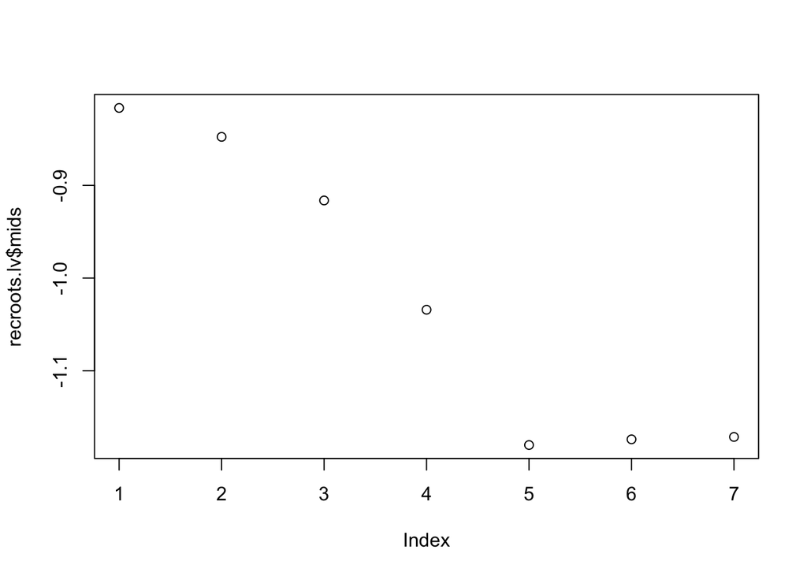

```r
plot(recroots.lv$mids)
```

```r
hinkley(roots)
```

```
##         h
## 0.6344084
```

```r
hinkley(logs)
```

```
##         h
## 0.1242494
```

```r
hinkley(recroots)
```

```
##          h
## -0.1618581
```

This plot above looks better than the plot with taking log.

Looking at the values of d in Hinkley’s quick method, the correct reexpression appears to be between p=0 and p=-1/2, although the value closest to 0 corresponds to the log reexpression.

Now, we are going to take an alternative form of this power transformation that is p=-0.2

```r
#An Alternative form of this power transformation
new <-((lake$Wshed ^ -0.2)-1)/-0.2
aplpack::stem.leaf(new)
```

```
## 1 | 2: represents 1.2
##  leaf unit: 0.1
##             n: 71
##     3    -1. | 888
##     9    -1* | 333000
##    12    -0. | 775
##    22    -0* | 3333222211
##   (17)    0* | 00000000000133333
##    32     0. | 5566666666688999
##    16     1* | 223
##    13     1. | 5577899
##     6     2* | 01
##     4     2. | 5899
```

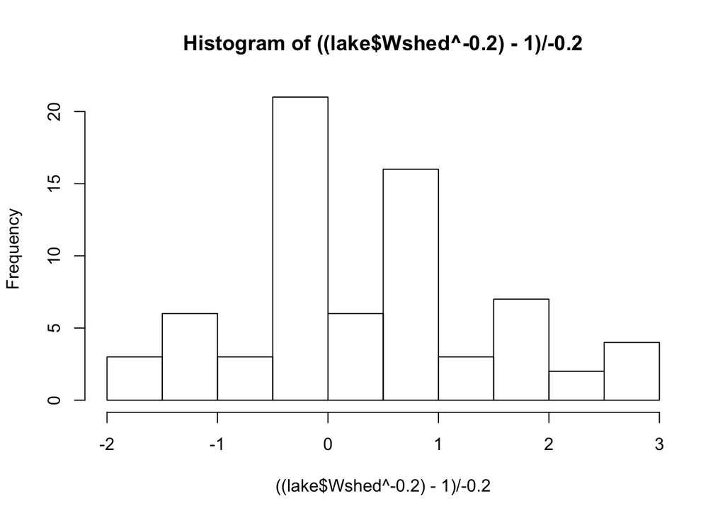

```r
hist(((lake$Wshed ^ -0.2)-1)/-0.2)
```

This histgram looks roughly symmetric.

```r
new.lv <- lval(new)
new.lv
```

```
##   depth         lo        hi      mids  spreads
## M  36.0  0.3894604 0.3894604 0.3894604 0.000000
## H  18.5 -0.2281978 0.9862922 0.3790472 1.214490
## E   9.5 -0.8745570 1.7732218 0.4493324 2.647779
## D   5.0 -1.3612982 2.1628636 0.4007827 3.524162
## C   3.0 -1.8986483 2.8303617 0.4658567 4.729010
## B   2.0 -1.8986483 2.9186170 0.5099843 4.817265
## A   1.0 -1.8986483 2.9579166 0.5296342 4.856565
```

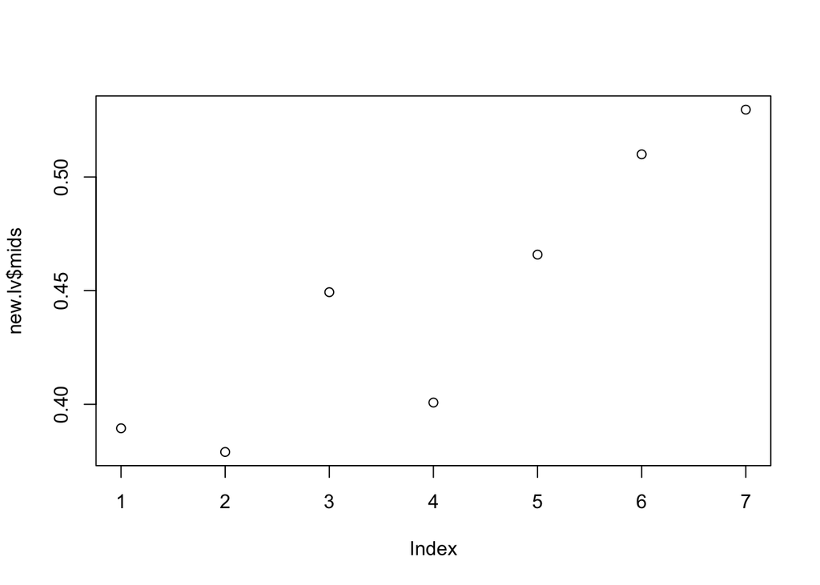

```r
plot(new.lv$mids)
```